# TP3_logistic_regression

## TP3 : Logistic regression

The purpose of this tutorial is to implement and use the Logistic Regression for binary classification. We will apply this method to the problem of handwritten characters to learn how to distinguish two numbers (here 5 and 6).

```python
from pylab import *
import numpy as np
import matplotlib.pyplot as plt
from numpy import linalg as la
import seaborn as sns
```

## 1. Logistic regression, IRLS algorithm.

### Preliminary question: the algorithm

#### Have a look at the function `regression_logistique.m` and locate the main steps of the algorithm you have been taught (see course).

You can comment the code in the cell below.

```python
def regression_logistique(X,t,Nitermax=20,eps_conv=1e-3):
    '''
    Entrees :
    X = [ones(N_train,1) x_train];
    t = class_train;
    Nitermax = nombre maximale d'itérations (20 par défaut)
    eps_conv = critère de convergence sur norm(w-w_old)/norm(w) ;
    eps_conv = 1e-3 par défaut

    Sorties :
    w : vecteur des coefficients de régression logistique
    Niter : nombre d'itérations utilisées effectivement
    Fonction de régression logistique pour la classification binaire.
    Utilisation :
       Nitermax = 50
       eps_conv = 1e-4
       [w,Niter] = regression_logistique(X,t,Nitermax,eps_conv)

    '''
    N_train = X.shape[0]

    #initialisation : 1 pas de l'algorithme IRLS
    w = np.zeros((X.shape[1],))
    w_old = w
    y = 1/2*np.ones((N_train,))
    R = np.diag(y*(1-y))   # diag(y_n(1-y_n))
    z = X.dot(w_old)-la.inv(R).dot(y-t)
    w = la.inv(X.T.dot(R).dot(X)).dot(X.T).dot(R).dot(z)

    # boucle appliquant l'algorithme de Newton-Raphson
    Niter = 1
    while ( (la.norm(w-w_old)/la.norm(w)>eps_conv) & (Niter<Nitermax) ):
        Niter = Niter+1
        y = 1/(1+np.exp(-X.dot(w)))
        R = np.diag(y*(1-y))
        w_old = w
        z = X.dot(w_old)-la.inv(R).dot(y-t)
        w = la.inv(X.T.dot(R).dot(X)).dot(X.T).dot(R).dot(z)

    return w, Niter
```

### Reading & preparing synthetic data

Load the training and test data sets `synth_train.txt` and `synth_test.txt`. The targets t belong to {1,2} and the features  
x belong to R^2.

We have 100 training samples and 200 test samples

- the 1st column contains the label of each sample,
- columns 2 and 3 contain the coordinate of each point.

```python
# Training set
synth_train = np.loadtxt('synth_train.txt')
class_train = synth_train[:,0]
class_train_1 = np.where(synth_train[:,0]==1)[0]
class_train_2 = np.where(synth_train[:,0]==2)[0]
x_train = synth_train[:,1:]

N_train = np.size(x_train,axis=0)
# Test set
synth_test = np.loadtxt('synth_test.txt')
class_test = synth_test[:,0]
class_test_1 = np.where(synth_test[:,0]==1)[0]
class_test_2 = np.where(synth_test[:,0]==2)[0]
x_test = synth_test[:,1:]
N_test = np.size(x_test,axis=0)
```

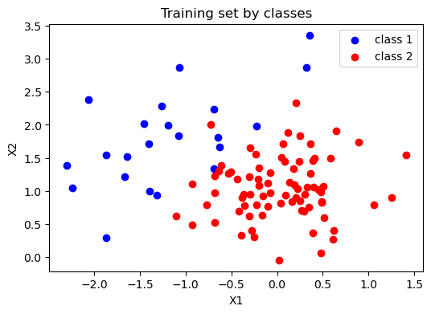

```python
plt.figure(figsize=(6, 4))
plt.scatter(x_train[class_train_1][:,0], x_train[class_train_1][:,1], color="b", label="class 1")
plt.scatter(x_train[class_train_2][:,0], x_train[class_train_2][:,1], color="r", label="class 2")
plt.xlabel("X1")
plt.ylabel("X2")
plt.legend()
plt.title("Training set by classes")
plt.show()
```

### Preparing features for logistic regression (binary classification)

First, we prepare the feature matrix and the target vector associated to the training and test sets:

```python
X = np.hstack((np.ones((N_train,1)),x_train))
t = 2-class_train   # 0 if class=2, 1 if class=1

X_test = np.hstack((np.ones((N_test,1)),x_test))
t_test = 2-class_test   # 0 if class=2, 1 if class=1
```

### Exercise 1 : the logistic function of decision

1. Use the function `regression_logistique.m` to estimate the logistic regression vector `w`. Indication : use

   ```
   Nitermax = 50;
   eps_conv=1e-3;
   ```

   .
2. Compute the decision function $f(x) = argmax_k P(C_k|x)$ on the test set to get the classification results. Recall that $y_n=\sigma(w^T x)$ (logistic function) and that *using vectors* you may directly write $y=\sigma(Xw)$, with the column of ones in X.
3. Display the results by plotting the points from both the training set and the test set.
4. Write the equation which defines the decision boundary.
5. Artificially add a few points to the training set far from the decision boundary to check the robustness of logistic regression to outliers. Check the behaviour of LDA for comparison in this case and comment.
1. Use the function `regression_logistique.m` to estimate the logistic regression vector `w`. Indication : use

   ```
   Nitermax = 50;
   eps_conv=1e-3;
   ```

   .

```python
#Exercise 1
Nitermax = 50
w, Niter = regression_logistique(X, t, Nitermax=50, eps_conv=1e-3)
print("Regression coefficients : ", w)
print(f"The algorithme converge after {Niter} iterations")
```

```
Regression coefficients :  [-15.206658    -7.91866363   6.56243114]
The algorithme converge after 9 iterations
```

2- the decision function $f(x) = argmax_k P(C_k|x)$ on the test set to get the classification results

```python
def sigmoid(x):
    return 1/(1 + np.exp(-x))
#Décision function
def decision(x, w):
    return argmax([1 - sigmoid(np.dot(x, w.T)), sigmoid(np.dot(x, w.T))], axis=0)
#Error
def error(pred, truth):
    return (np.sum([pred != truth]))/truth.shape[0]
```

```python
pred = np.array(decision(X_test, w)) #Let's see our prédictions
```

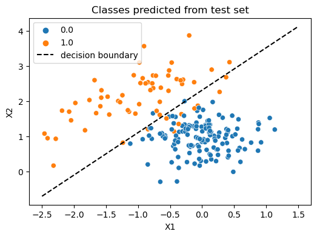

```python
plt.figure(figsize=(6, 4))
sns.scatterplot(x=X_test[:, 1], y=X_test[:, 2], hue=t_test)
#plt.scatter(x_test[np.where(pred - t_test !=0),0], x_test[np.where(pred - t_test !=0),1], color="black", label="points mal classés")
#Decision boundary
plt.xlabel("X1")
plt.ylabel("X2")
plt.legend()
plt.title("Classes predicted from test set")
x1 = np.linspace(-2.5,1.5,10)
x2 = (-w[0]-w[1]*x1)/w[2]
plt.plot(x1,x2,'k--', label="decision boundary")
plt.legend()
plt.show()
```

```python
print("Prediction error : ",error(pred, t_test))
```

```
Prediction error :  0.06
```

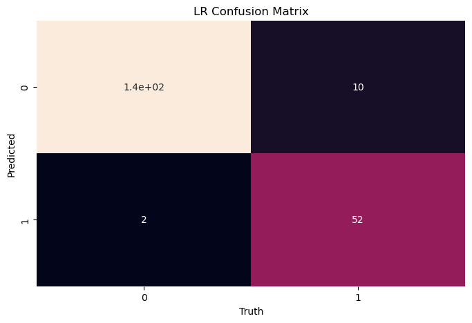

```python
from sklearn.metrics import confusion_matrix
pred_test = decision(X_test, w)
cm = confusion_matrix(pred_test, t_test)
tn, fp, fn, tp = cm.ravel()
plt.figure(figsize=(8, 5), facecolor='white')
plt.title("LR Confusion Matrix")
sns.heatmap(cm, annot=True, cbar=False)
plt.xlabel("Truth")
plt.ylabel("Predicted")
plt.show()
```

#### Conclusions :

- As we said earlier we have some wrong classifications but still with 0.06 error we could say that our model is great .
- Predicting the minority class (class 1) poses a challenge, a common issue encountered with logistic regression models. To address this, we may consider both oversampling and undersampling the data. It's worth noting that logistic regression models tend to exhibit greater robustness with larger datasets, and as such, undersampling may lead to a decrease in performance.
- Equation of the decision boundary:

$\sigma(w^T x) = 0.5$ which implies that $w^T x = 0$ $\newline$ $w^T x = 0$ $\Leftrightarrow$ $w_{0}+ w_{1}x_{1} + w_{2}x_{2} = 0$ $\newline$ et donc : $x_{2} = - \frac{w_{0}}{w_{2}} - \frac{w_{1}}{w_{2}}x_{1}$

```python
print(f"The decision boundary equation : y = {round(-w[1]/w[2],1)}x + {round(-w[0]/w[2],1)}")
```

```
The decision boundary equation : y = 1.2x + 2.3
```

#### Test of the robustness of logistic regression to outliers

##### Adding outliers to our data :

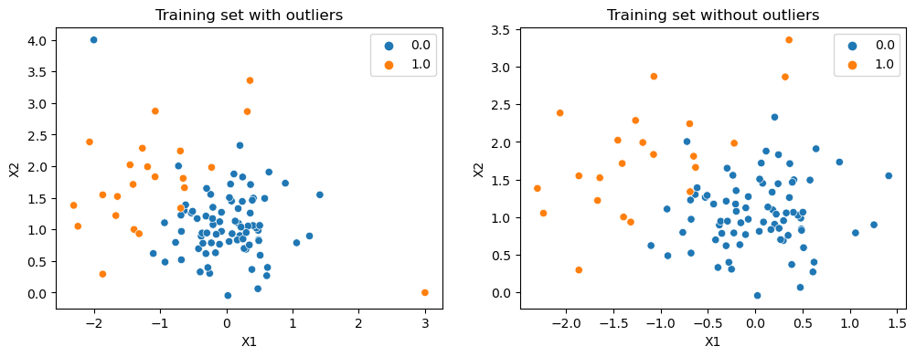

```python
# Outliers
X_with_outliers = np.vstack((X, np.array([[1, 3, 0], [1, -2, 4]])))
t_with_outliers = np.hstack((t, np.array([1,0])))

# plot les données avec outliers
fig, axs = plt.subplots(1, 2, figsize=(12, 4))

sns.scatterplot(x=X_with_outliers[:, 1], y=X_with_outliers[:, 2], hue=t_with_outliers, ax=axs[0])
axs[0].set_title("Training set with outliers")
axs[0].set_xlabel("X1")
axs[0].set_ylabel("X2")

sns.scatterplot(x=X[:, 1], y=X[:, 2], hue=t, ax=axs[1])
axs[1].set_title("Training set without outliers")
axs[1].set_xlabel("X1")
axs[1].set_ylabel("X2")

plt.show()
```

```python
# regression logistique avec outliers
w_with_outlier, Niter = regression_logistique(X_with_outliers, t_with_outliers, Nitermax=50, eps_conv=1e-3)
print("Regression coefficients : ", w_with_outlier)
print(f"The algorithme converge after {Niter} iterations")
```

```
Regression coefficients :  [-3.96976236 -1.84119542  1.39958658]
The algorithme converge after 5 iterations
```

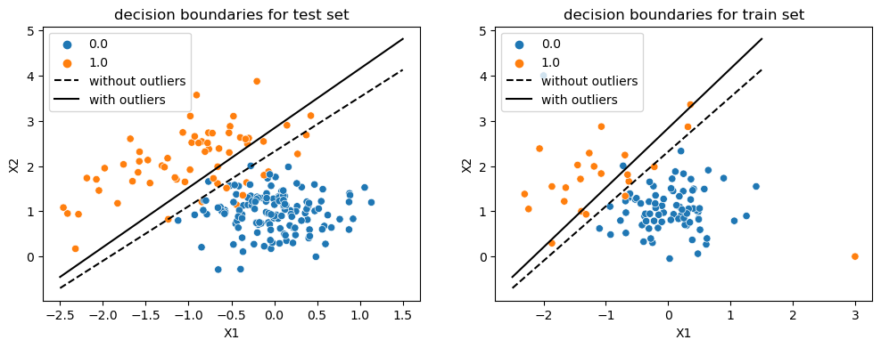

```python
# plot les données avec outliers avec la frontière de décision et calcul de l'erreur
pred = np.array(decision(X_test, w_with_outlier)) #Let's see our prédictions
fig, axs = plt.subplots(1, 2, figsize=(12, 4))

sns.scatterplot(x=X_test[:, 1], y=X_test[:, 2], hue=t_test, ax=axs[0])
#Decision boundary
axs[0].set_xlabel("X1")
axs[0].set_ylabel("X2")
axs[0].legend()
axs[0].set_title("decision boundaries for test set")
x1 = np.linspace(-2.5,1.5,10)
x2 = (-w[0]-w[1]*x1)/w[2]
x2_outlier = (-w_with_outlier[0]-w_with_outlier[1]*x1)/w_with_outlier[2]
axs[0].plot(x1,x2,'k--', label="without outliers")
axs[0].plot(x1,x2_outlier,'k', label="with outliers")
axs[0].legend()

sns.scatterplot(x=X_with_outliers[:, 1], y=X_with_outliers[:, 2], hue=t_with_outliers, ax=axs[1])
#Decision boundary
axs[1].set_xlabel("X1")
axs[1].set_ylabel("X2")
axs[1].legend()
axs[1].set_title("decision boundaries for train set")
x1 = np.linspace(-2.5,1.5,10)
x2 = (-w[0]-w[1]*x1)/w[2]
x2_outlier = (-w_with_outlier[0]-w_with_outlier[1]*x1)/w_with_outlier[2]
axs[1].plot(x1,x2,'k--', label="without outliers")
axs[1].plot(x1,x2_outlier,'k', label="with outliers")
axs[1].legend()

plt.show()
```

```python
print("Prediction error : ",error(pred, t_test))
```

```
Prediction error :  0.075
```

#### LDA robustness to outliers :

```python
from sklearn.discriminant_analysis import LinearDiscriminantAnalysis

LinearClassifier = LinearDiscriminantAnalysis(store_covariance=True)
LinearClassifier.fit(X=x_train,y=t)

LinearClassifier_new = LinearDiscriminantAnalysis(store_covariance=True)
LinearClassifier_new.fit(X=X_with_outliers[:,1:], y=t_with_outliers)


t_test_pred_without_outliers = LinearClassifier.predict(x_test)
test_error_without_outliers = error(t_test_pred_without_outliers,t_test)

t_test_pred_with_outliers = LinearClassifier_new.predict(x_test)
test_error_with_outliers = error(t_test_pred_with_outliers,t_test)

print(f"Test error without outliers = {test_error_without_outliers}")
print(f"Test error with outliers = {test_error_with_outliers}")
```

```
Test error without outliers = 0.055
Test error with outliers = 0.085
```

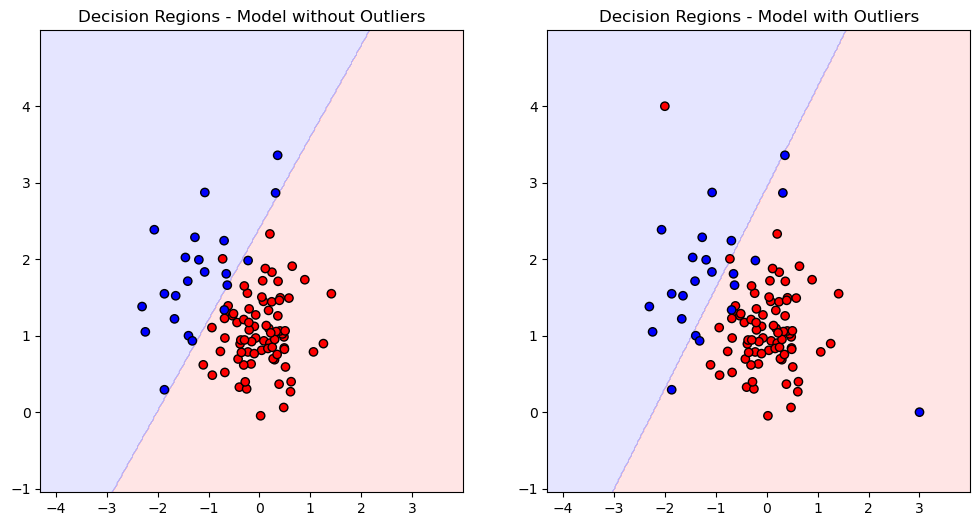

```python
from matplotlib.colors import ListedColormap

h = 0.02  # taille du pas dans la grille
x_min, x_max = X_with_outliers[:, 1].min() - 2, X_with_outliers[:, 1].max() + 1
y_min, y_max = X_with_outliers[:, 2].min() - 1, X_with_outliers[:, 2].max() + 1
xx, yy = np.meshgrid(np.arange(x_min, x_max, h), np.arange(y_min, y_max, h))

# Prédire la classe pour chaque point de la grille avec le premier modèle
Z1 = LinearClassifier.predict(np.c_[xx.ravel(), yy.ravel()])
Z1 = Z1.reshape(xx.shape)

# Prédire la classe pour chaque point de la grille avec le deuxième modèle
Z2 = LinearClassifier_new.predict(np.c_[xx.ravel(), yy.ravel()])
Z2 = Z2.reshape(xx.shape)

# Tracer les régions de décision avec les limites de décision
cmap_background = ListedColormap(['#FFAAAA', '#AAAAFF'])
cmap_points = ListedColormap(['#FF0000', '#0000FF'])

plt.figure(figsize=(12, 6))

plt.subplot(1, 2, 1)
plt.contourf(xx, yy, Z1, cmap=cmap_background, alpha=0.3)
plt.scatter(x_train[:, 0], x_train[:, 1], c=t, cmap=cmap_points, edgecolors='k', marker='o')
plt.title('Decision Regions - Model without Outliers')

plt.subplot(1, 2, 2)
plt.contourf(xx, yy, Z2, cmap=cmap_background, alpha=0.3)
plt.scatter(X_with_outliers[:, 1], X_with_outliers[:, 2], c=t_with_outliers, cmap=cmap_points, edgecolors='k', marker='o')
plt.title('Decision Regions - Model with Outliers')

plt.show()
```

## 2. Application: handwritten digits recognition 5 & 6

We load 2 matrices which contain each a sequence of examples of 16x16 images of handwritten digits which are 5 and 6 here. Each line of the matrix contains 256 pixel values coding for the gray level of a 16x16 image.

```python
train_5 = np.loadtxt('train_5.txt',delimiter=',')   # 556 samples
train_6 = np.loadtxt('train_6.txt',delimiter=',')   # 664 samples
```

```python
train_5.shape
```

```
(556, 256)
```

```python
train_6.shape
```

```
(664, 256)
```

#### Examples of images

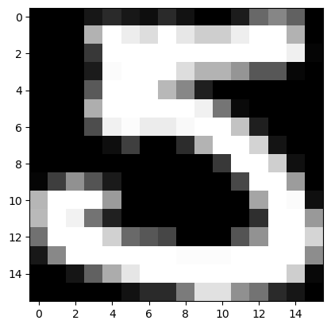

```python
# Digit 5
n=0
I = np.reshape(train_5[n,:],(16,16))

plt.imshow(I,cmap='gray')
plt.show()
```

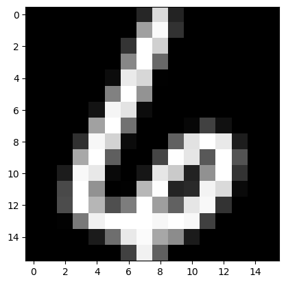

```python
# Digit 6
n=3
I = reshape(train_6[n,:],(16,16))

plt.imshow(I,cmap='gray')
plt.show()
```

### Separating the training and test sets

We keep in the training set the 145 first images of 5s and the 200 first images of 6s:

```python
x_train_brut = np.vstack((train_5[:145,:], train_6[:200,:]))
N_train = np.size(x_train_brut,axis=0)
class_train = np.ones((345,1))   # label 1 for digit 6
class_train[:145] = 0       # label 0 for digit 5

x_test_brut = np.vstack((train_5[145:,:], train_6[200:,:]))
N_test = np.size(train_5,axis=0)+np.size(train_6,axis=0)-N_train

class_test = np.ones((N_test,1))   # label 1 for digit 6
class_test[:411] = 0       # label 0 for digit 5
```

## Exercise 2: logistic regression to classify 5 & 6

1. Note that pixel values are between -1 and 1 by using the functions `min(I(:))` and `max(I(:))`.
2. Identify the indices of the most significant pixels, which are defined as having a standard deviation greater than 0.5 here. We denote by `lis_sig` the list of positions of these significant pixels in the image vector. _Indication : the function `std` gives the standard deviation (columnwise in matrices) and you should find 173 pixel positions.
3. Show a binary image to locate these pixels. _Indication : `Isig = zeros(16); Isig(list_sig)=1; Isig=Isig';`._
4. Define the training set `x_train` from `x_train_brut` from the significant pixels only.
5. Do the same with `x_test_brut` to extract `x_test`.
6. Use `regression_logistique.m` to estimate the logistic regression vector `w` from the training set `x_train`. Choose `Nitermax = 13; eps_conv = 1e-3;`
7. Compute the decision function and the labels of the test set `x_test`. *Indication : do not forget the column of ones !*
8. Estimate the classification error rate by using : `erreur = sum(abs(class-class_test))/N_test;`.
9. Locate some misclassified examples and visualize the corresponding image. Comment on your results and observations.

```python
import numpy as np

# Assuming I is the image matrix
min_val = np.min(I)
max_val = np.max(I)

print(f"Minimum pixel value: {min_val}")
print(f"Maximum pixel value: {max_val}")
```

```
Minimum pixel value: -1.0
Maximum pixel value: 1.0
```

```python
# Compute the standard deviation of each pixel
std_dev = np.std(x_train_brut, axis=0)

# Find the indices of the most significant pixels
list_sig = np.where(std_dev > 0.5)[0]

# Print the number of significant pixels found
print(f"Number of significant pixels: {len(list_sig)}")
```

```
Number of significant pixels: 173
```

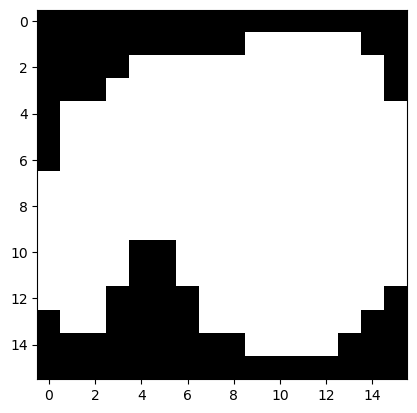

```python
Isig = np.zeros((16,16))
Isig[np.unravel_index(list_sig, (16,16))] = 1
Isig = Isig.T

plt.imshow(Isig, cmap='gray')
plt.show()
```

```python
# 4. Define the training set x_train from x_train_brut from the significant pixels only.
x_train_img = x_train_brut[:, list_sig]
x_train_img = np.hstack((np.ones((N_train,1)),x_train_img))
# 5. Do the same with x_test_brut to extract x_test.
x_test_img = x_test_brut[:, list_sig]
x_test_img = np.hstack((np.ones((N_test,1)),x_test_img))

# 6. Use regression_logistique.m to estimate the logistic regression vector w from the training set x_train. Choose Nitermax = 13; eps_conv = 1e-3;
Nitermax = 13
eps_conv = 1e-3
w, Niter = regression_logistique(x_train_img, class_train.reshape((345,)), Nitermax=Nitermax, eps_conv=eps_conv)
```

```python
# 7. Compute the decision function and the labels of the test set x_test. Indication : do not forget the column of ones !
Class = np.array(decision(x_test_img, w))

# 8. Estimate the classification error rate by using : erreur = sum(abs(class-class_test))/N_test;.
erreur = np.sum(np.abs(class_test.reshape(875,) - Class))/N_test
accuracy = 1 - erreur
print(f"Classification error rate: {erreur}")
print(f"Accuracy: {accuracy}")
cm = confusion_matrix(class_test.reshape(875,) , Class)
print(cm)
misclassified_indices = np.where(class_test.reshape(875,)  != Class)[0]
print(f"Number of misclassified examples: {len(misclassified_indices)}")
```

```
Classification error rate: 0.07885714285714286
Accuracy: 0.9211428571428572
[[366  45]
 [ 24 440]]
Number of misclassified examples: 69
```

Le modèle fait un total de 69 erreurs : 45 chiffres 5 ont été identifiés à tort comme des 6, avec un taux d'erreur de 45/411 = 0,11, et 24 chiffres 6 ont été identifiés à tort comme des 5, avec un taux d'erreur de 24/464 = 0,05. Cela signifie que proportionnellement, il y a plus d'erreurs sur les chiffres 5. Cela semble être lié au fait qu'il y avait plus de chiffres 6 que de chiffres 5 dans l'ensemble d'entraînement. En conséquence, le système semble très capable de reconnaître les chiffres 6, mais il n'a pas été suffisamment entraîné pour reconnaître correctement les chiffres 5 : c'est une forme de surajustement.

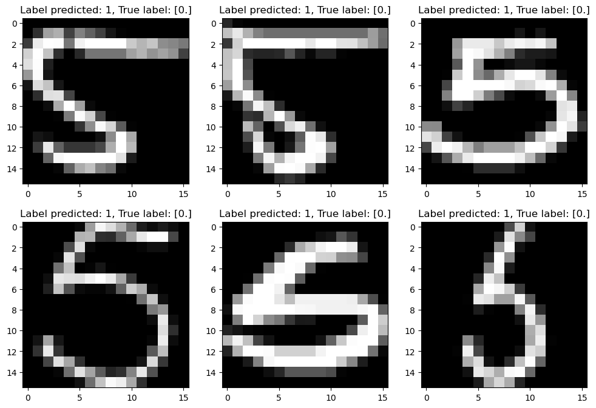

```python
# 9. Locate some misclassified examples and visualize the corresponding image. Comment on your results and observations.
plt.figure(figsize=(12, 8))
for i in range(6):
    n = misclassified_indices[i]
    I = np.reshape(x_test_brut[n,:],(16,16))
    ax = plt.subplot(2, 3, i + 1)
    ax.set_title(f"Label predicted: {Class[n]}, True label: {class_test[n]}")
    plt.imshow(I,cmap='gray')
```

On peut dire qu'il est compréhensible que certains des chiffres 5 mentionnés précédemment aient été confondus avec des 6. En particulier l'espace vers le bas à gauche est parfois très réduit, ce qui pourrait être une raison de confondre un 5 avec un 6.

## 3. Logistic regression using `scikit-learn`

1. **Go to** http://scikit-learn.org/stable/modules/generated/sklearn.linear_model.LogisticRegression.html for a presentation of the logistic regression model in `scikit-learn`.
2. **Apply** it to the present data set.
3. **Comment** on the use of logistic regression.

*Indication : you may have a look at*

a) Theory : http://openclassroom.stanford.edu/MainFolder/DocumentPage.php?course=MachineLearning&doc=exercises/ex5/ex5.html

b) Video : https://kr.coursera.org/lecture/machine-learning/regularized-logistic-regression-cAxpF

c) Example : http://scikit-learn.org/stable/auto_examples/exercises/plot_digits_classification_exercise.html#sphx-glr-auto-examples-exercises-plot-digits-classification-exercise-py

*for a short presentation of regularized logistic regression.*

```python
# Include your code here
from sklearn.linear_model import LogisticRegression
from sklearn.metrics import accuracy_score


logistic_classifier = LogisticRegression()
logistic_classifier.fit(x_train_img, class_train.reshape((345,)))

# Predictions on the training set
train_predictions = logistic_classifier.predict(x_train_img)

# Predictions on the test set
test_predictions = logistic_classifier.predict(x_test_img)
```

```python
# Calculate accuracy on training set
train_accuracy = accuracy_score(class_train.reshape((345,)), train_predictions)
print(f"Training Accuracy: {train_accuracy}")

# Calculate accuracy on test set
test_accuracy = accuracy_score(class_test.reshape(875,), test_predictions)
print(f"Test Accuracy: {test_accuracy}")

# Confusion Matrix for test set
conf_matrix = confusion_matrix(class_test.reshape(875,), test_predictions)
print("Confusion Matrix:")
print(conf_matrix)
```

```
Training Accuracy: 1.0
Test Accuracy: 0.9737142857142858
Confusion Matrix:
[[400  11]
 [ 12 452]]
```

Commentaires : Nous constatons que sklearn parvient à effectuer des prédictions meilleures que notre propre implémentation de la régression logistique. En effet, sklearn utilise une régression logistique régularisée qui contribue à réduire le surajustement causé par le déséquilibre entre le nombre de 5 et le nombre de 6.